# MICB425 Portfolio - Microbial Ecological Genomics: From Genomes to Biomes, Spring 2018

Zijie John Zhu (11656148)

version April 24, 2018

# Module 01

## Data science Friday

### Installation check

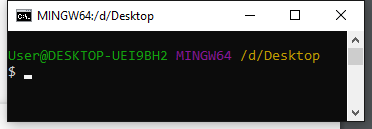

[figure not shown]

[figure not shown]

### Portfolio repo setup

*Set up Git user locally*

```
git config --global user.name $USERNAME
git config --global user.email $EMAIL
```

*Creating local repository*

```
cd $REPO_DIR
git init
git add .
git commit -m "Initial commit"
git remote add origin $REPO_URL
git remote -v
git push -u origin master
```

### RMarkdown pretty PDF challenge

[output not shown]

### Plotting data in R

Installing Phyloseq

```r
source("https://bioconductor.org/biocLite.R")
biocLite("phyloseq")
```

Load libraries & data

```r
library(tidyverse)
library(phyloseq)
metadata=read.table(file="module_1/Saanich.metadata.txt", header=TRUE, row.names=1, sep="\t", na.strings="NAN")
load("module_1/phyloseq_object.RData")
```

Plot 1: Simple scatterplot

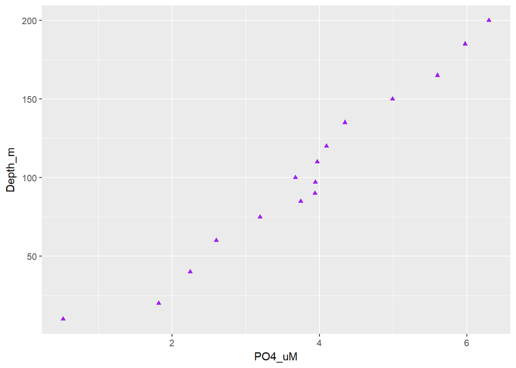

```r
ggplot(metadata, aes(x=PO4_uM, y=Depth_m)) +
  geom_point(shape=17, color="purple")
```

Plot 2: Plot dplyr mutated data

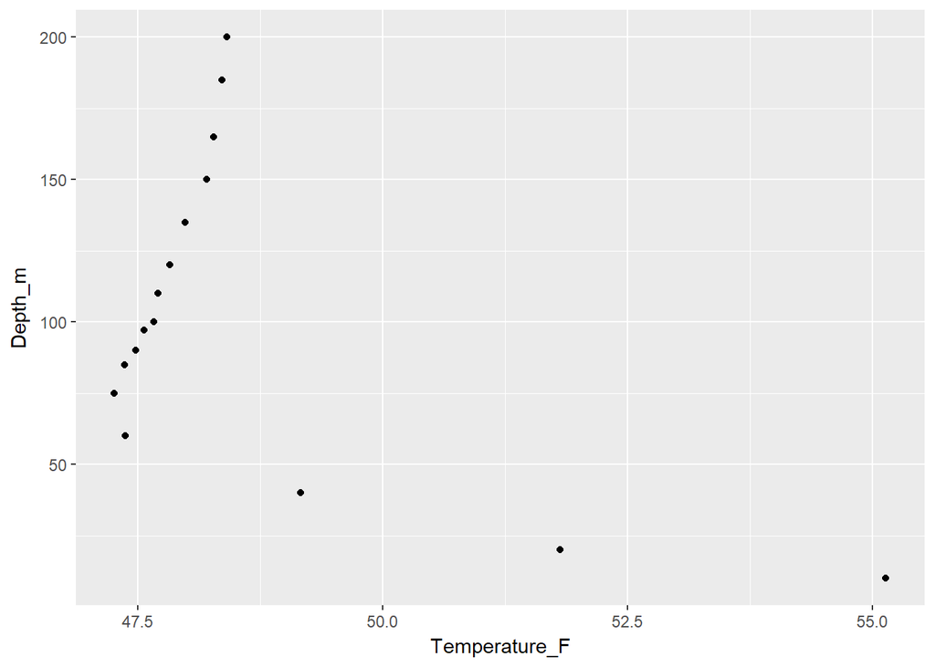

```r
metadata %>%
  mutate(Temperature_F = Temperature_C * 9/5 + 32) %>%  # convert C to F
  ggplot(aes(x=Temperature_F, y=Depth_m)) +
  geom_point()
```

Plot 3: Plot using Phyloseq mutated data & adding labels

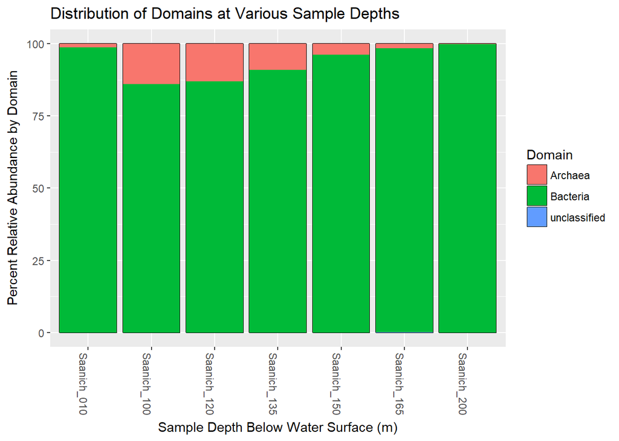

```r
physeq_percent = transform_sample_counts(physeq, function(x) 100 * x/sum(x)) # transform to relative abundance
plot_bar(physeq_percent, fill="Domain") +
  geom_bar(aes(fill=Domain), stat="identity") +
  labs(y="Percent Relative Abundance by Domain", x="Sample Depth Below Water Surface (m)",
       title="Distribution of Domains at Various Sample Depths")
```

Plot 4: Faceted plot using tidied data

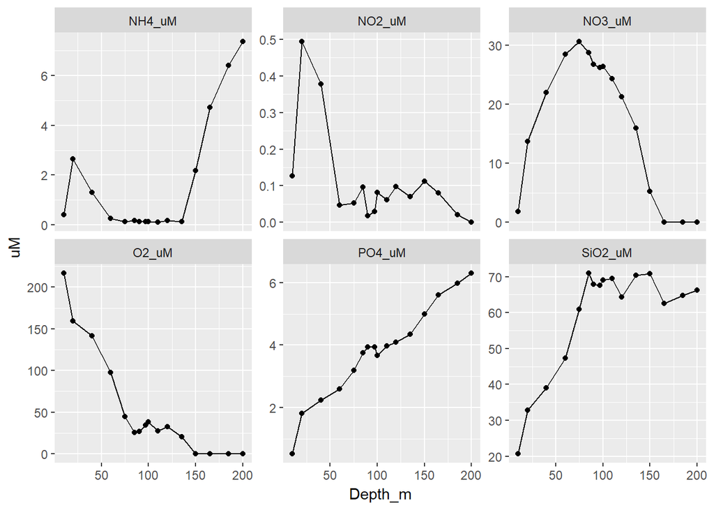

```r
metadata %>%
  select(Depth_m, NH4_uM, NO2_uM, NO3_uM, O2_uM, PO4_uM, SiO2_uM) %>%
  gather(Nutrient,uM,-Depth_m) %>% # tidy the data
  ggplot(aes(x=Depth_m, y=uM)) +
  geom_line() + geom_point() + # line plot with points
  facet_wrap(~Nutrient, scales="free_y") + # facet the plot
  theme(legend.position="none") # remove the legend
```

## Origins and Earth Systems

### Evidence worksheet 01

[Whitman *et al* 1998](https://www.ncbi.nlm.nih.gov/pmc/articles/PMC33863/) *Prokaryotes: The unseen majority*

#### Learning objectives

Describe the numerical abundance of microbial life in relation to ecology and biogeochemistry of Earth systems.

#### General questions

- What were the main questions being asked?

  What is the total number, density, carbon mass, growth and turnover rates of prokaryotic organisms in aquatic, soil, and subsurface environments?
- What were the primary methodological approaches used?

  This study is a review of other published literature. The authors presented data from other studies of aquatic, soil, and subsurface environments, and presented them in a tabular form. The authors then extrapolate the remaining data so that values of cell densities, abundances, and carbon contents are complete for each environment. Lastly the authors conduct comparative analyses based on these data and address these questions.
- Summarize the main results or findings.
  - Total prokaryotic carbon on Earth is estimated to be 60~100% of the carbon mass found in plants.
  - Prokaryotes have approx. one order of magnitude more of total N and P mass than that in plants, because they contain much more N and P relative to carbon than plants do.
  - Total protoplasmic biomass on Earth in microbes is far higher than plants
  - Lower limit in prokaryotic turnover time ranges from 6-25 days to ~1000 days (1-2 thousand years for subsurface bacteria, however it is far longer than expected and is based on one sample)
  - 0.4, 0.5, 3.4, and 170 hours avg for 4 mutations from the pool of all genes shared by marine heterotrophs (in the upper 200 m), marine autotrophs, soil prokaryotes, or prokaryotes in domestic animals
  - 60 years avg for 5 mutations from the pool of all genes shared by all 4 groups
- Do new questions arise from the results?

  Why is the subsurface turnover rate so slow?  
  Which hypothesis is true: metabolic inactivity, lithotrophic metabolism, overestimation of subsurface biomass, underestimation of carbon assimilation?
- Were there any specific challenges or advantages in understanding the paper (*e.g.* did the authors provide sufficient background information to understand experimental logic, were methods explained adequately, were any specific assumptions made, were conclusions justified based on the evidence, were the figures or tables useful and easy to understand)?

  Could clarify what is âfour simultaneous mutations in every gene shared by the populations of marine heterotrophsâ a bit more.

### Problem set 01

[Whitman *et al* 1998](https://www.ncbi.nlm.nih.gov/pmc/articles/PMC33863/) *Prokaryotes: The unseen majority*

#### Learning objectives

Describe the numerical abundance of microbial life in relation to the ecology and biogeochemistry of Earth systems.

#### Specific questions

- What are the primary prokaryotic habitats on Earth and how do they vary with respect to their capacity to support life? Provide a breakdown of total cell abundance for each primary habitat from the tables provided in the text.

  The habitats are **aquatic, soil,** and **subsurface**

  Total cell abundances:

  Aquatic: $1.181E29$ cells  
  Soil: $2.556E29$ cells  
  Subsurface: $3.8E30$ cells

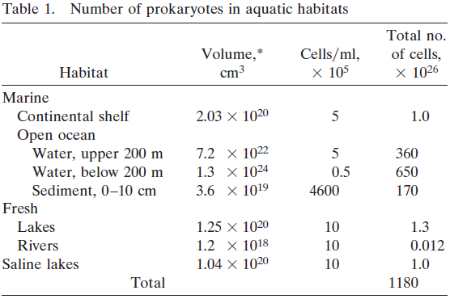

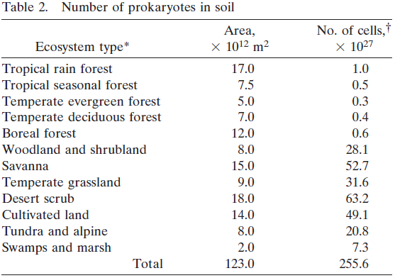

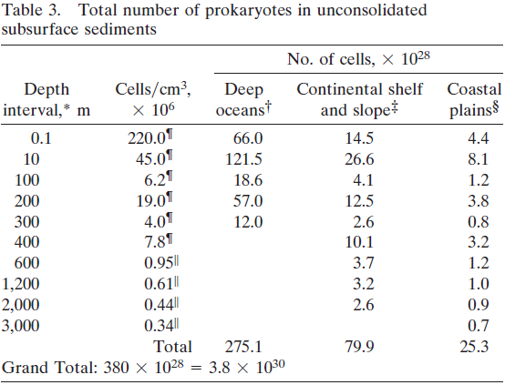

- What is the estimated prokaryotic cell abundance in the upper 200 m of the ocean and what fraction of this biomass is represented by marine cyanobacterium including Prochlorococcus? What is the significance of this ratio with respect to carbon cycling in the ocean and the atmospheric composition of the Earth?

  The estimated prokaryotic cell abundance is 5E5 cells/mL, or 360E26 cells total.  
  Marine cyanobacteria & Procholorococcus account for 4E4 of the cells per mL, or 8% of all prokaryotic cells in the top 200m.  
  They are responsible for atmospheric oxygenation and carbon assimilation.
- What is the difference between an autotroph, heterotroph, and a lithotroph based on information provided in the text?

  Autotroph: Energy source independent of organic substrates  
  Heterotroph: Energy source from organic carbon substrates  
  Lithotroph: Energy source from inorganic substrates
- Based on information provided in the text and your knowledge of geography what is the deepest habitat capable of supporting prokaryotic life? What is the primary limiting factor at this depth?

  At a subsurface depth of 4km, the average temperature is 125C.  
  This is close to the temperature limit for prokaryotic life.  
  The high temperature is likely due to geothermal processes.  
  On average, the temperature increases by 22 degrees Celsius per km depth.
- Based on information provided in the text your knowledge of geography what is the highest habitat capable of supporting prokaryotic life? What is the primary limiting factor at this height?

  Prokaryotic life has been detected in the air at very low qualtities up to 57-77km (more likely 20km realistically).  
  The low temperature & pressure as well as extreme solar radiation are limiting factors at this height.  
  However it is arguable that the atmosphere is capable of supporting growth (as opposed to transport) due to the lack of many essential nutrients at any appreciable concentrations.
- Based on estimates of prokaryotic habitat limitation, what is the vertical distance of the Earthâs biosphere measured in km?

  If including the atmosphere, Earth’s biosphere spans from approx. 20km above the summit of Mt. Everest to approx. 4.5km below the Marianas Trench. This amounts to approx. 44km.
- How was annual cellular production of prokaryotes described in Table 7 column four determined? (Provide an example of the calculation)

  Annual cellular production is the population size mutiplied by the number of turnover periods in a year.  
  For marine heterotrophs above 200m:  
  Population size = $3.6E28$ cells  
  Turnover period = $16$ days  
  Annual cellular production = population * turnover/yr = $3.6E28\frac{365}{16} = 8.215E29$ cells/yr  
  *Aside*: Viruses play a significant role in driving this turnover. Viruses often carry accesorry metabolism genes (AMG) which directly modulates cellular metabolism. At a larger scale, this in turn modulates the metabolism of the community.
- What is the relationship between carbon content, carbon assimilation efficiency and turnover rates in the upper 200m of the ocean? Why does this vary with depth in the ocean and between terrestrial and marine habitats?

  A number of assumptions need to be made to establish these relationships.

  Assuming:  
  20% carbon assimilation efficiency (growth efficiency, substrate use efficiency)  
  We can estimate that amount of C required per turnover to be:  
  4 * 0.72 = 2.88Pg (unclear why the author used a factor of 4 instead of 5)

  Assuming:  
  The net primary production in terms of C is 51Pg/yr and  
  85% of it is consumed in the top 200m, all by prokaryotes  
  We can estimate that the amount of C available per year is:  
  51 * 0.85 = 43Pg/yr

  This works out to 43/2.88 = 14.9 turnovers per year or 24.5 days
- How were the frequency numbers for four simultaneous mutations in shared genes determined for marine heterotrophs and marine autotrophs given an average mutation rate of 4 x 10<sup>-7</sup> per DNA replication? (Provide an example of the calculation with units. Hint: cell and generation cancel out)

  The probability of 4 simultaneous mutations would be (4E-7)<sup>4</sup> = 2.56E-26 per replication.

  The prokaryotic genomes have tremendous abilities to change given high mutation rates, large population size, and rapid turnover rates. By accumulating mutations not only through point mutations but also through insertion, deletion, HGT and recombination, mutations can rapidly spread horizontally and vertically. This makes the world of prokaryotes incredibly diverse and adaptable to any kind of biologically viable habitat.
- What relationships can be inferred between prokaryotic abundance, diversity, and metabolic potential based on the information provided in the text?

  Since there is high diversity, there is also a wide range of metabolic capabilities.  
  Since there is also high abundance, the impact/extent of metabolism on the Earth is also very large - enough to oxygenate the atmosphere, for example.

### Evidence Worksheet 02

[Kasting & Siefert, 2002](https://www.ncbi.nlm.nih.gov/pubmed/12004117) *Life and the evolution of Earth’s atmosphere*

[Nisbet & Sleep, 2001](https://www.nature.com/articles/35059210) *The habitat and nature of early life*

#### Learning objectives

Comment on the emergence of microbial life and the evolution of Earth systems

#### General Questions

- Indicate the key events in the evolution of Earth systems at each approximate moment in the time series. If times need to be adjusted or added to the timeline to fully account for the development of Earth systems, please do so.
- Describe the dominant physical and chemical characteristics of Earth systems at the following waypoints
  - **Hadean**  
    Hot & dry  
    Often molten due to constant bombardment  
    Oceans cannot form  
    CO2 tied up in minerals
    - 4.6 billion years ago  
      Inner solar system formed  
      Water vapour & carbon (as CO2 in limestone) deposited on Earth  
      Hot (500C)
    - 4.5 billion years ago  
      Moon forming impact led to Earth spin, tilt, generated diurnal cycle & seasons Rock vapour atmosphere formed (optically thick) Hot (~100C) for 2 million years Late heavy bombardments - Frequent large scale bombardments raise temp over 100C
    - 4.4 billion years ago Zircons formed
    - 4.1 billion years ago Evidence of life found in graphite in Zircons
    - 4.0 billion years ago  
      Evidence of plate subduction Oldest rock - Acasta gneiss from Canada
  - **Archean**  
    Cooldown of Earth  
    Oceans formed Early sun is still dim (30% dimmer)  
    Methanogenesis kept Earth from freezing
    - 3.8 billion years ago  
      Bombardments halted  
      Oceans formed  
      Evidence of sedimentary rocks  
      Seawater chemistry stabilized Evidence of life in carbon isotopes too
    - 3.75 billion years ago  
      Evidence of photosynthesis
    - 3.5 billion years ago  
      Microfossils, stromatolites Evidence of isotopic partition of C from carbonate Most likely Rubisco global oxygenic photosynthesis
    - 3.0 billion years ago  
      First glaciation event - oxygen stops methanogensis
    - 2.7 billion years ago  
      Evidence of cyanobacteria & eukaryotes
  - **Proterozoic**  
    Oxygeneated atmosphere  
    Increased complexity of life
    - 2.2 billion years ago  
      Great oxidation event - sharp increase in O2 (may involve complex eukaryotes)  
      Evidence of redbeds containing iron oxide  
      Regulation of mitochondria & chloroplasts may modulate balance of photosynthesis, CO2 & N fixation
    - 2.1 billion years ago Oxygenic photosynthesis in cyanobacteria
    - 1.2 billion years ago Evidence of sexual reproduction
  - **Phanerozoic**  
    Evolution of higher organisms  
    Several extinction events Very high atmospheric oxygenation at one point, correlated to gigantism
    - 500 million years ago Cambrian explosion
    - 400 million years ago Devonian explosion - land plants Fish, cephalopods, corals formed
    - 300 million years ago Gigantism Formation of Pangae
    - 250 million years ago Permian extinction
    - 240 million years ago Evidence of dinosours
    - 200 million years ago Triassic Jurassic extinction event
    - 60 million years ago Creataceous Tertiary extinction event
    - 550,000 years ago Archaic humans first appear
    - 200,000 years ago Homo sapiens first appear

### Problem set 02

[Falkowski *et al* 2008](https://www.ncbi.nlm.nih.gov/pubmed/18497287) *The microbial engines that drive Earth’s biogeochemical cycles*

#### Learning objectives

Discuss the role of microbial diversity and formation of coupled metabolism in driving global biogeochemical cycles.

#### Specific Questions

- What are the primary geophysical and biogeochemical processes that create and sustain conditions for life on Earth? How do abiotic versus biotic processes vary with respect to matter and energy transformation and how are they interconnected?

  The primary geophysical and biogeochemical processes are plate tectonics & atmospheric photochemical processes. They allow distribution, resupply, and reaction between chemical species & nutrients.

  Abiotic processes are primarily acid-base (H ions), because most of molecular H has escaped to space during Earth’s formation, whereas biotic processes are primarily redox (electrons).
- Why is Earthâs redox state considered an emergent property?

  Since biological processes are largely redox based, and Earth’s abiotic processes interacts and ultimately drive the biological processes, Earth’s redox state is a property tightly linked to its biosphere, thus it’s considered an emergent property.
- How do reversible electron transfer reactions give rise to element and nutrient cycles at different ecological scales? What strategies do microbes use to overcome thermodynamic barriers to reversible electron flow?

  Since much of microbial metabolism involves redox reactions of the 6 major elements, the sum of metabolism at the micro scale transforms the plant at the macro scale.  
  Microbes take advantage of Le Chatelier’s principle, which can moderate thermodynamic favourability by limiting the relative abundance of reaction products and reactants.  
  Methane oxidizing organisms form mutualistic relationships with hydrogen-consuming sulfate reducers. Through continued consumption of hydrogen, its concentration remains low, making methane oxidization favorable.  
  Similarly, the TCA cycle which oxidizes organic carbon into CO2 is also run in reverse in carbon fixing bacteria such as GSBs.
- Using information provided in the text, describe how the nitrogen cycle partitions between different redox ânichesâ and microbial groups. Is there a relationship between the nitrogen cycle and climate change?

  N cycling involves many different redox niches and microbial group. Nitrogen fixation is carried out solely anaerobically by nitrogenase. Ammonia is oxidized to nitriate or nitrite aerobically by nitrifying bacteria. Another reductive process used by yet other microbes anaerobically reduce ntrite and nitrate to dinitrogen. Different microbes that run parts of this cycle are often segregated in time and/or space, due to different requirements in reaction conditions.

  N cycling and climate change may be related in that nitrifying bacteria undergo carbon fixation & assimilation by reducing CO2 while oxidizing ammonia, thus reducing atmospheric CO2.
- What is the relationship between microbial diversity and metabolic diversity and how does this relate to the discovery of new protein families from microbial community genomes?

  Metabolic and microbial diversity are often, but not always correlated. For example, the presence of fundamental metabilic processes does not reflect the actual microbial diversity. Neither do simple pathways such as rhodopsin based photosynthesis.
- On what basis do the authors consider microbes the guardians of metabolism?

  Since the “core planetary gene set” which enables the fundamental metabilic processes is widespread in diverse species of microbes, the extinction of even the majority of the species does not necessarily mean the loss of this set. This microbes as a whole are considered as guardians of metabolism.

### Evidence worksheet 03

[Waters et al 2016](https://www.ncbi.nlm.nih.gov/pubmed/26744408) *The Anthropocene is functionally and stratigraphically distinct from the Holocene*

#### Learning objectives

Evaluate human impacts on the ecology and biogeochemistry of Earth systems

#### General questions

- What were the main questions being asked?

  What are some stratigraphic signatures in sediments and ice that reflect human activities which support the designation of the Anthropocene epoch?
- What were the primary methodological approaches used?

  This article is a review, summarizing findings of primary literature.
- Summarize the main results or findings.

  Geological evidence showed
  - Traces of elemental aluminum, concrete, plastics from developlent of modern materials
  - Traces of carbonaceous particles from fossil fuel burning
  - Increased polyaromatic hydrocarbons, PCBs, pesticide from synthetic chemicals
  - Changed lead isotopic ratios from burning of leaded gasoline
  - Increased rates of sedimentation due to increased erosion
  - Elevated levels of nitrogen and phosphorus in lake strata & Greenland ice
  - Elevated levels of radioisotopes C-14 and Pu-239 due to thermonuclear weapons tests
  - Steep fall in C-13 ratio captured in tree rings, limestones, and calcareous fossils associated with elevated atmospheric CO2 and CH4 starting around 1850-1950
  - Increased temperature, O-18 ratio in Greenland ice, and rising global sea levels beyond Holocene levels

  Additionally there is increased rates of extinction and changes in species composition due to human exploitation and species invasion.
- Do new questions arise from the results?

  Should we formalize the Anthropocene as a stratigraphic entity like other epochs? Should we simply keep it informal like the Precambrian?  
  How should we define the Anthropocene, by GSSA (calendar age), and/or GSSP (stratal section)? When does it formally begin?
- Were there any specific challenges or advantages in understanding the paper (*e.g.* did the authors provide sufficient background information to understand experimental logic, were methods explained adequately, were any specific assumptions made, were conclusions justified based on the evidence, were the figures or tables useful and easy to understand)?

  Since the focus of this article is on stratigraphic/geologic evidence, the discussion of species extinction and diversity sounds a bit out of place. But otherwise the discussion was easy to follow.

### Module Essay

*“Microbial life can easily live without us; we, however, cannot survive without the global catalysis and environmental transformation it provides.” Do you agree or disagree with this statement? Answer the question using specific references to your reading, discussions and content from evidence worksheets and problem sets.*

Microbial life is ubiquitous. Although mostly invisible to the naked eye, microbes are in fact orders of magnitude more abundant in number than that of visible higher life forms with which we are familiar. Microbes have also inhabited Earth since the Archean eon (Nisbet & Sleep, 2003). Humans, on the other hand, have only come into existence extremely recently in geological time, inevitablY dependent upon the works of the “unseen majority” (Whitman & Wiebe, 1998). Unsurprisingly, microbial metabolism on Earth then becomes a cornerstone of the elemental fluxes in practically every major biologically relevant geochemical cycle. Microbes can, and have, lived on a planet without humans; however humans would not have existed, nor can they continue to survive, without the global catalysis and environmental transformations carried out by microbes. This becomes apparent when considering the key fluxes of the global oxygen, nitrogen, and carbon cycles.

From the perspective of oxygen cycle, microbial life not only has laid the foundation of aerobic respiration, but also continues to supply a substantial amount of molecular oxygen today. Humans respire aerobically, using oxygen as a terminal electron acceptor at the end of cellular electron transport chains (ETC). By deriving electrons from organic carbon sources and relaying them through the ETC, cells transform energy in the form of redox potentials into ATP, the cellular energy currency. However, the atmosphere was anoxic until approximately 2.5-2.3 Gya (Kirschvink & Kopp, 2008; Kump & Barley, 2007). Moreover, the earliest evidence of Rubisco, the key enzyme for oxygenic photosynthesis, was dated at 3.5 Gya (Nisbet & Sleep, 2003, Schidlowski & Aharon, 1992). This provides strong evidence that microbial oxygenic photosynthesis initially provided the molecular oxygen required for the development of aerobic respiration carried out by humans. Additionally, oxygen generated by photosynthesis in oceanic ecosystems is approximately on-par with that of terrestrial ecosystems (Walker et al. 1980). Therefore microbial metabolism contributes approximately half of the global oxygen output. If microbial life had not existed, or were to suddenly be halted, atmospheric oxygen concentrations would not remain at levels necessary to support human life. Microbial sources of oxygen has not only once played, but also continues to play, a crucial role in human survival.

From the perspective of the nitrogen cycle, we rely on microbes for a balanced cycle necessary to sustain current ecosystems. If we are to grow independent of global microbial catalysis, we must artificially replace microbial geochemical fluxes, which means developing industrial processes at sufficient scales. This implies both pervasiveness and volume. Consider nitrification for instance. Nitrifying bacteria are pervasive, converting soil ammonia to nitrates, which are sources of preferred nitrogen by some plants due to their higher diffusion rates compared to ammonia (Raven et al. 1992). If all microbial metabolism were to halt, we would not be able to carry out nitrification at a scale pervasive enough to resupply every ecosystem with the nitrates currently supplied by microbes, using modern day technology. Additionally, while chemically possible, we do not yet have the technology to perform abiotic nitrification with a significant flux to effectively contribute to the global nitrogen cycle. In fact, we commonly rely on microbial metabolism for large scale nitrification, such as wastewater treatment. Lack of microbial nitrification may lead to depletion of soil nitrates, in turn disrupting global flora diversity. Furthermore, even if abiological processes with significant rates exist we would still be challenged with difficulties in integrating them amongst other fluxes while maintaining existing nutrient balance. This is exemplified by the nitrogen-fixing Haber-Bosch process. It is the primary source of nitrogen for fertilizers, and accounts for approximately a third to a quarter of global nitrogen fixation, at about 100 Tg/yr (Ward 2012). However their use often results in eutrophication of nearby still waters due to an over-abundance of nitrogen introduced by agricultural effluent (Callisto et al. 2013). Microbial metabolic fluxes in the nitrogen cycle is irreplaceable due to the sheer pervasiveness, volume, and the intricacy of flux balance required to maintain current global ecosystems.

Perhaps most significantly, from the perspective of the carbon cycle, humans rely on microbial life to globally decay and respire substantial amounts of biomass. As heterotrophs, humans gain energy by oxidizing organic carbon to inorganic carbon dioxide. Therefore we must depend on a continuous source of organic carbon, which ultimately originates from plant primary production. Microbial metabolism plays a critical role in replenishing the atmospheric carbon required by primary production. It is estimated that microbial metabolism accounts for approximately half of all terrestrial soil respiration, or approximately 51-60 Pg/yr of carbon (Hashimoto et al., 2015; Shao et al., 2013). Microbes also carry out virtually all biological respiration in the open ocean, at approximately 66 Pg/yr of carbon (del Giorgio & Duarte 2002). Without global microbial decomposition, dead biomass would easily accumulate as humans would not be able to decompose biomass at a global scale. This limits global replenishment of carbon dioxide, ultimately impacting primary productivity. Thus humans rely on microbial metabolism to catalyze global biomass decay to support primary productivity.

Microbial life can easily live without us; we, however, cannot survive without the global catalysis and environmental transformations it provides. This is exemplified through some of the key roles of microbial metabolism within 3 major biogeochemical cycles. Microbial metabolism oxygenated the atmosphere, enabling aerobic respiration. Microbial metabolism fixes dinitrogen and nitrifies reduced nitrogen species pervasively and with globally significant flux, as well as denitrifies while maintaining ecosystem nutrient balance. Microbial metabolism also replenishes atmospheric carbon by respiring biomass, thereby making carbon available to for primary production. While microbes can, and have, persisted without the presence of humans, human existence must be supported by the continuous nutrient flux resulting from microbial metabolism. We may think that humans are at the helm of Space Ship Earth (Achenbach, 2012), however it is crucial to realize that the ship is powered by microbes, without which neither we, nor most other higher life forms, can survive. If all microbial metabolism were to suddenly halt, Earth will seemingly come under the grasp of an invisible disease, which may see all remaining life on Earth slowly grind to a halt, as all usable forms of nutrients cease to exist.

# Module 02

## Remapping the body of the world

### Problem set 03

[Madsen 2005](https://www.ncbi.nlm.nih.gov/pubmed/15864265) *Identifying microorganisms responsible for ecologically significant biogeochemical processes*

[Wooley et al. 2009](https://www.ncbi.nlm.nih.gov/pubmed/20195499) *A Primer on Metagenomics*

#### Learning objectives:

Specific emphasis should be placed on the process used to find the answer. Be as comprehensive as possible e.g. provide URLs for web sources, literature citations, etc.

#### Specific Questions:

- How many prokaryotic divisions have been described and how many have no cultured representatives (microbial dark matter)?

  As of 2013, 60 divisions have been described, half of which were not cultured [(Rinke et al. 2013)](https://www.nature.com/articles/nature12352)
- How many metagenome sequencing projects are currently available in the public domain and what types of environments are they sourced from?

  The Joint Genome Institute’s Genomes Online Database (JGI GOLD) currently [lists](https://gold.jgi.doe.gov/studies?Study.Metagenomic+Study=Yes&Study.Is+Public=Yes#) 51.5k public metagenome sequencing projects, and 1.4k studies.  
  JGI GOLD currents lists the following ecosystem types:

  ```
  Activated Sludge, Aerobic, Agricultural field, Anaerobic, Anaerobic digestor, Aquaculture, Ascidians, Asteroidea, Bacteria, Beetle, Biochar, Bone, Breviatea, Brown Algae, Bryozoans, Canal, Circulatory system, City, Cnidaria, Composting, Continuous culture, Ctenophora, Currency notes, Dairy products, Deep subsurface, Defined, Defined media, Digestive system, Dinoflagellates, Endosphere, Engineered product, Excretory system, Eye, Fermented beverages, Fermented seafood, Fermented vegetables, Freshwater, Fungi, Gastrointestinal tract, Genetic cross, Geologic, Green algae, House, Hydrocarbon, Indoor Air, Industrial wastewater, Integument, Intracellular endosymbionts, Lab synthesis, Landfill, Leaf, Lichen, Lymphatic, Lymphatic system, Mammals, Marine, Meat products, Microbial enhanced oil recovery, Microbial solubilization of coal, Mixed alcohol bioreactor, Mollusca, Mycelium, Nematoda, Nervous system, Nodule, Non-marine Saline and Alkaline, Nutrient removal, Oil refinery, Oil reservoir, Oomycetes, Outdoor Air, Peat, Peat moss, Persistent organic pollutants (POP), Phylloplane, Phyllosphere, Plant litter, Platyhelminthes, Red algae, Reproductive system, Respiratory system, Rhizome, Rhizoplane, Rhizosphere, Rock-dwelling (subaerial biofilms), Roots, Sediment, Shell, Silage fermentation, Simulated communities (DNA mixture), Simulated communities (microbial mixture), Simulated communities (sequence read mixture), Skin, Soil, Solar panel, Solid animal waste, Spacecraft Assembly Cleanrooms, Sponge, Symbiotic fungal gardens and galleries, Tailings pond, Tetrachloroethylene and derivatives, Thermal springs, Thermal springs, Thiocyanate, Tissue, Tunicates, Unclassified, Undefined media, Volcanic, Water treatment plant, Whole body, Wood
  ```

- What types of on-line resources are available for warehousing and/or analyzing environmental sequence information (provide names, URLS and applications)?

  [SILVA](https://www.arb-silva.de/) is a database of over 8 million quality-checked and aligned small (16S, 18S) and large (23S and 28S) rRNA sequences from bacteria, archaea, and eukarya  
  [RefSeq](https://www.ncbi.nlm.nih.gov/refseq/) is a database of non-redundant, annotated, reference assembled genomic DNA, transcripts, and proteins  
  [JGI GOLD](https://gold.jgi.doe.gov/) is a database of global genome and metagenome sequencing projects. Projects are usually linked to RefSeq entries  
  [JGI IMG/M](https://img.jgi.doe.gov/) is a database of microbial genome and microbiome sequenced at JGI  
  [MG-RAST](http://www.mg-rast.org/) is an online server that annotates metagenomic data by comparing to both protein and nucleotide databases  
  [MEGAN](http://ab.inf.uni-tuebingen.de/software/megan6/welcome/) is an taxonomic and functional analysis toolbox which for microbiome data  
  [RDP](https://rdp.cme.msu.edu/) is a database of over 3 million quality-controlled, aligned and annotated Bacterial & Archaeal 16S, and funcal 28S rRNA sequences
- What is the difference between phylogenetic and functional gene anchors and how can they be used in metagenome analysis?  
  Phylogenetic anchors are genes which are characteristic to a taxonomic unit due to the accumulation of mutations through evolution/vertical transmission. Ideally they are single copy genes. Ther are also good for constructing phylogenetic trees. E.g.16S & 18S rRNA genes.  
  Functional anchors are protein encoding genes diagnostic of pathways & metabolic functions. They’re often horizontally transferred, so they’re not as useful for comparing phylogenies. E.g. nitrogenase.
- What is metagenomic sequence binning? What types of algorithmic approaches are used to produce sequence bins? What are some risks and opportunities associated with using sequence bins for metabolic reconstruction of uncultivated microorganisms?

  Metagenomic binning groups related sequences together into bins representing a single genome. This can be based on various measures such as GC content, codon usage, alignments to reference sequences, etc. Binning using sequences from uncultivated microorganisms potentially links predicted/potential metabolic functions to said uncultivated organisms. But on the flip side, it also risks mistakenly putting the sequence in the wrong bin, leading to contamination. Metagenomic data are usually incomplete, so we usually end up with incomplete genomes in each bin as well. Genetic variations within a species may also lead to binning sequences from the same species in separate bins. Ideally these should be binned together in which the bin itself contains the species-wise variation.
- Is there an alternative to metagenomic shotgun sequencing that can be used to access the metabolic potential of uncultivated microorganisms? What are some risks and opportunities associated with this alternative?

  An alternative to shotgun sequencing, i.e. shearing genomic DNA before sequencing, is 3rd generation sequencing. This technique requires much less (or no) shearing, as it works with long nucleotide sequences. It also does not require amplification like 2nd generation technologies because it works on a single molecule. Single cell sequencing technology can also be used in conjunction in which cells are separated before sequencing.  
  This may drastically reduce errors in binning. Since we can potentially sequence cells separately, we know where each sequence fragment came from. Longer sequences also resolve repetitive regions better, so we can assemble a more complete and accurate genome.  
  However 3rd generation sequencing is still in development. Presently it has a high error rate and lower degree of genome completeness Biochemical techniques are also possible, such as enrichment culturing where the growth media only supports the metabolic function desired. Imaging techniques such as FISH can also reveal the presence of conserved genomic sequences (DNA) or gene expression (RNA).

### Evidence worksheet 04

[Martinez et al. 2007](https://www.ncbi.nlm.nih.gov/pmc/articles/PMC1838496/) *Proteorhodopsin photosystem gene expression enables photophosphorylation in a heterologous host*

#### Learning objectives

Discuss the relationship between microbial community structure and metabolic diversity  
Evaluate common methods for studying the diversity of microbial communities  
Recognize basic design elements in metagenomic workflows

#### General questions

- What were the main questions being asked?

  What are the structure and function of a proteorhodopsin photosystem derived from a large-insert marine pickplankton DNA library?
- What were the primary methodological approaches used?

  Fosmid (F plasmid, single copy origin of replication; some have 2nd origin of replication that works with a mutant Rep protein induced by arabinose for indicible high copy) library prepared from ocean surface water picoplankton was introduced to E. coli. Fosmid copy number was controlled (via additional origin of replication) to be high or low, and retinal in growth was present or absent.  
  Transposon mutagenesis was used for genotypic and phenotypic analyses.

  **Development of a functional screen using metagenomic samples for a function of interest**
- Summarize the main results or findings.

  3 clones were found to be orange even in the absence of retinal when the fosmid was induced to have a high copy number. 2 clones were sequenced.  
  Proteorhodopsin gene was found in close proximity to beta carotene and retinal biosynthesis genes in both clones.  
  Both clones were derived from Alphaproteobacteria from the Mediterranean and Red Seas.  
  Both proteorhodopsin genes encoded glutamine at position 105, which was charcteristic of blue light absoroption.  
  Transposon insertion at the proteorhodopsin gene and 3 other beta carotene synthesis genes crtE,B,I revealed pale colonies. Disruption of crtY revealed pink colonies and accumulation of lycopene intermediate. Disruption of blh (beta carotene cleavage to retinal) revealed yellow colonies and accumulation of beta carotene intermediate.  
  Light dependent pH change detected for clones under high copy conditions but not mutants with transposon insertion at the proteorhodopsin gene, or those who can’t synthesize retinal.  
  Light induced increase in cellular ATP observed for only those with intact proteowhodopsin.  
  CCCP (makes membrane permeable to H+) eliminated light driven pH decrease.  
  DCCD (inhibits H+ ATPase) did not eliminate pH decrease but inhibited photophosphorylation.
- Do new questions arise from the results?

  While significant photophosphorylation was observed, does light stimulation actually increase growth rate? Earlier studies measuring this have been inconclusive.
- Were there any specific challenges or advantages in understanding the paper (*e.g.* did the authors provide sufficient background information to understand experimental logic, were methods explained adequately, were any specific assumptions made, were conclusions justified based on the evidence, were the figures or tables useful and easy to understand)?

  Functional screening using essentially single long DNA fragments ignores the possibility that parts of a photosystem may also reside in multuple distant operons, perhaps even utilizing enzymes & intermediate from other pathways.  
  Perhaps one or two sentences providing an overview of fosmids and copy number control mechanisms could be useful. Otherwise the language, figures, and explanations were relatively straightforward.

## References

1. Madsen EL. Identifying microorganisms responsible for ecologically significant biogeochemical processes. Nat Rev Microbiol. 2005;3(5):439-46.
2. Martinez A, Bradley AS, Waldbauer JR, Summons RE, Delong EF. Proteorhodopsin photosystem gene expression enables photophosphorylation in a heterologous host. Proc Natl Acad Sci USA. 2007;104(13):5590-5.
3. Wooley JC, Godzik A, Friedberg I. A primer on metagenomics. PLoS Comput Biol. 2010;6(2):e1000667.

# Module 03

## Microbial Species Concepts

### Problem set 04 “Fine-scale phylogenetic architecture”

#### Learning objectives:

- Gain experience estimating diversity within a hypothetical microbial community

#### Part 1: Description and enumeration

Obtain a collection of “microbial” cells from “seawater”. The cells were concentrated from different depth intervals by a marine microbiologist travelling along the Line-P transect in the northeast subarctic Pacific Ocean off the coast of Vancouver Island British Columbia.

Sort out and identify different microbial “species” based on shared properties or traits. Record your data in this Rmarkdown using the example data as a guide.

Once you have defined your binning criteria, separate the cells using the sampling bags provided. These operational taxonomic units (OTUs) will be considered separate “species”. This problem set is based on content available at [What is Biodiversity](http://cnx.org/content/m12179/latest/).

For example, load in the packages you will use.

```r
#To make tables
library(kableExtra)
library(knitr)
#To manipulate and plot data
library(tidyverse)
```

Then load in the data. You should use a similar format to record your community data.

```r
community_data = data.frame(
  number = c(1,2,3,4,5,6,7,8,9,10,11,12,13,14),
  name = c("Gummy Bear","Brick","Jube Jube","Kisses","M&M","Mike & Ike","Skittles","Sour Bear","Sour Bottle","Sour Fruit","Sour Octopus","Sour Swirl","Vine","Wine Gum"),
  characteristics = c("Clear/Green/Yellow/Orange/Light red/Dark red","Large/small, Yellow/Green/Blue/Red","Green, Orange, Red, Yellow, Purple","Silver","Blue/Brown/Yellow/Orange/Green/Red","Green/Light red/Dark red/Yellow/Orange","Green/Purple/Orange/Red/Yellow","Red/Yellow/Blue","2 colours per piece","Watermelon/Berry","Blue head, 2 tentacle colours per piece","Blue/Red","Red","Various wine flavours"),
  occurrences = c(101,18,24,16,241,174,187,3,3,2,6,3,14,9)
)
```

Finally, use these data to create a table.

```r
community_data %>%
  kable("html") %>%
  kable_styling(bootstrap_options = "striped", font_size = 10, full_width = F)
```

| number | name | characteristics | occurrences |
| --- | --- | --- | --- |
| 1 | Gummy Bear | Clear/Green/Yellow/Orange/Light red/Dark red | 101 |
| 2 | Brick | Large/small, Yellow/Green/Blue/Red | 18 |
| 3 | Jube Jube | Green, Orange, Red, Yellow, Purple | 24 |
| 4 | Kisses | Silver | 16 |
| 5 | M&M | Blue/Brown/Yellow/Orange/Green/Red | 241 |
| 6 | Mike & Ike | Green/Light red/Dark red/Yellow/Orange | 174 |
| 7 | Skittles | Green/Purple/Orange/Red/Yellow | 187 |
| 8 | Sour Bear | Red/Yellow/Blue | 3 |
| 9 | Sour Bottle | 2 colours per piece | 3 |
| 10 | Sour Fruit | Watermelon/Berry | 2 |
| 11 | Sour Octopus | Blue head, 2 tentacle colours per piece | 6 |
| 12 | Sour Swirl | Blue/Red | 3 |
| 13 | Vine | Red | 14 |
| 14 | Wine Gum | Various wine flavours | 9 |

For your sample:

- Construct a table listing each species, its distinguishing characteristics, the name you have given it, and the number of occurrences of the species in the collection.
- Ask yourself if your collection of microbial cells from seawater represents the actual diversity of microorganisms inhabiting waters along the Line-P transect. Were the majority of different species sampled or were many missed?

#### Part 2: Collector’s curve

To help answer the questions raised in Part 1, you will conduct a simple but informative analysis that is a standard practice in biodiversity surveys. This analysis involves constructing a collector’s curve that plots the cumulative number of species observed along the y-axis and the cumulative number of individuals classified along the x-axis. This curve is an increasing function with a slope that will decrease as more individuals are classified and as fewer species remain to be identified. If sampling stops while the curve is still rapidly increasing then this indicates that sampling is incomplete and many species remain undetected. Alternatively, if the slope of the curve reaches zero (flattens out), sampling is likely more than adequate.

To construct the curve for your samples, choose a cell within the collection at random. This will be your first data point, such that X = 1 and Y = 1. Next, move consistently in any direction to a new cell and record whether it is different from the first. In this step X = 2, but Y may remain 1 or change to 2 if the individual represents a new species. Repeat this process until you have proceeded through all cells in your collection.

For example, we load in these data.

```r
collectors_curve_data = data.frame(
  x = c(1,2,3,4,5,6,7,8,9,10,11,12,13,14,15,16,17,18,19,20,21,22,23,24,25,26,27,28,29,30,31,32,33,34,35,36,37,38,39,40,41,42,43,44,45,46,47,48,49,50,51,52,53,54,55,56,57,58,59,60,61,62,63,64,65,66,67,68,69,70,71,72,73,74,75,76,77,78,79,80,81,82,83,84,85,86,87,88,89,90,91,92,93,94,95,96,97,98,99,100,101,102,103,104,105,106,107),
  y = c(1,2,3,3,3,3,4,5,6,6,6,7,7,7,7,7,7,7,7,7,7,7,7,7,7,7,8,9,10,10,10,10,10,10,10,10,10,11,11,11,11,11,11,11,11,11,11,11,11,11,11,11,11,11,11,11,11,11,11,11,11,11,11,11,11,11,11,11,11,11,11,11,11,11,11,11,11,11,11,11,11,11,11,11,11,11,11,11,11,11,11,11,11,11,11,11,11,11,11,11,11,11,11,11,11,11,11)
)
```

And then create a plot. We will use a scatterplot (geom_point) to plot the raw data and then add a smoother to see the overall trend of the data.

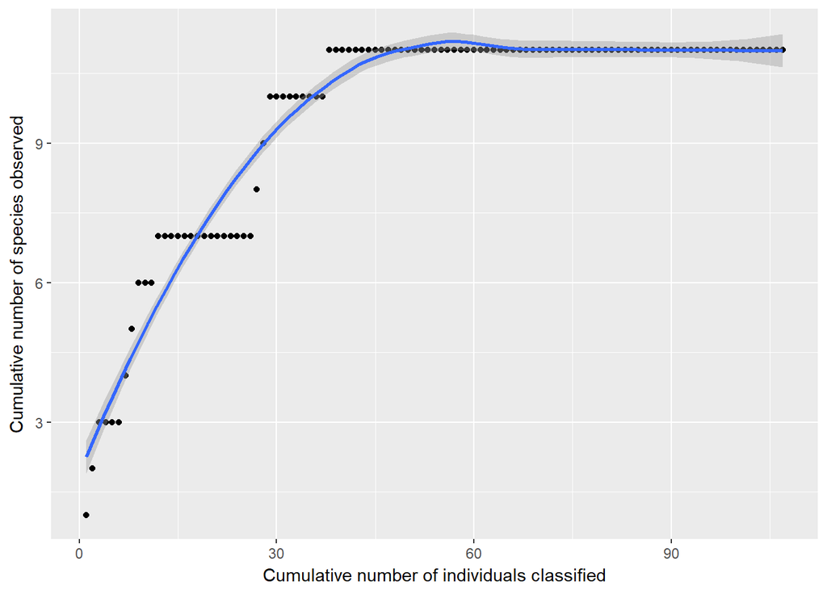

```r
ggplot(collectors_curve_data, aes(x=x, y=y)) +
  geom_point() +
  geom_smooth() +
  labs(x="Cumulative number of individuals classified", y="Cumulative number of species observed")
```

For your sample:

- Create a collector’s curve.
- Does the curve flatten out? If so, after how many individual cells have been collected?

  The curve flattens out after approx. 50 individuals.
- What can you conclude from the shape of your collector’s curve as to your depth of sampling?

  The sampling is adequate because the the curve is flat when all of the individuals are counted.

#### Part 3: Diversity estimates (alpha diversity)

Using the table from Part 1, calculate species diversity using the following indices or metrics.

##### Diversity: Simpson Reciprocal Index

$\frac{1}{D}$ where $D = \sum p_i^2$

$p_i$ = the fractional abundance of the $i^{th}$ species

For example, using the example data 1 with 3 species with 2, 4, and 1 individuals each, D =

```r
species1 = 2/(2+4+1)
species2 = 4/(2+4+1)
species3 = 1/(2+4+1)

1 / (species1^2 + species2^2 + species3^2)
```

```
## [1] 2.333333
```

The higher the value is, the greater the diversity. The maximum value is the number of species in the sample, which occurs when all species contain an equal number of individuals. Because the index reflects the number of species present (richness) and the relative proportions of each species with a community (evenness), this metric is a diveristy metric. Consider that a community can have the same number of species (equal richness) but manifest a skewed distribution in the proportion of each species (unequal evenness), which would result in different diveristy values.

- What is the Simpson Reciprocal Index for your sample?

```r
simpson_D = 0
community_count = sum(community_data$occurrences)
for (i in 1:length(community_data$number)) {
  simpson_D = simpson_D + (community_data$occurrences[i] / community_count) ^ 2
}
1 / simpson_D
```

```
## [1] 4.75165
```

##### Richness: Chao1 richness estimator

Another way to calculate diversity is to estimate the number of species that are present in a sample based on the empirical data to give an upper boundary of the richness of a sample. Here, we use the Chao1 richness estimator.

$S_{chao1} = S_{obs} + \frac{a^2}{2b})$

$S_{obs}$ = total number of species observed a = species observed once b = species observed twice or more

So for our previous example community of 3 species with 2, 4, and 1 individuals each, $S_{chao1}$ =

```r
3 + 1^2/(2*2)
```

```
## [1] 3.25
```

- What is the chao1 estimate for your sample?

```r
community_species_count = length(community_data$number)
observed_once = 0
observed_multiple_times = 0
for (i in 1:length(community_data$number)) {
  if (community_data$occurrences[i] == 1) {
    observed_once = observed_once + 1
  } else {
    observed_multiple_times = observed_multiple_times + 1
  }
}
community_species_count + (observed_once ^ 2) / (2 * observed_multiple_times)
```

```
## [1] 14
```

#### Part 4: Alpha-diversity functions in R

We’ve been doing the above calculations by hand, which is a very good exercise to aid in understanding the math behind these estimates. Not surprisingly, these same calculations can be done with R functions. Since we just have a species table, we will use the `vegan` package. You will need to install this package if you have not done so previously.

```r
library(vegan)
```

First, we must remove the unnecesary data columns and transpose the data so that `vegan` reads it as a species table with species as columns and rows as samples (of which you only have 1).

```r
community_data_diversity =
  community_data %>%
  select(name, occurrences) %>%
  spread(name, occurrences)

community_data_diversity
```

```
##   Brick Gummy Bear Jube Jube Kisses M&M Mike & Ike Skittles Sour Bear
## 1    18        101        24     16 241        174      187         3
##   Sour Bottle Sour Fruit Sour Octopus Sour Swirl Vine Wine Gum
## 1           3          2            6          3   14        9
```

Then we can calculate the Simpson Reciprocal Index using the `diversity` function.

```r
diversity(community_data_diversity, index="invsimpson")
```

```
## [1] 4.75165
```

And we can calculate the Chao1 richness estimator (and others by default) with the the `specpool` function for extrapolated species richness. This function rounds to the nearest whole number so the value will be slightly different that what you’ve calculated above.

```r
specpool(community_data_diversity)
```

```
##     Species chao chao.se jack1 jack1.se jack2 boot boot.se n
## All      14   14       0    14        0    14   14       0 1
```

In Project 1, you will also see functions for calculating alpha-diversity in the `phyloseq` package since we will be working with data in that form.

For your sample:

- What is the Simpson Reciprocal Index using the R function?

  See above code blocks
- What is the chao1 estimate using the R function?
  - Verify that these values match your previous calculations.

  See above code blocks. Previous calculations were accurate.

#### Part 5: Concluding activity

If you are stuck on some of these final questions, reading the [Kunin et al. 2010](https://www.ncbi.nlm.nih.gov/pubmed/19725865) and [Lundin et al. 2012](https://www.ncbi.nlm.nih.gov/pubmed/23760801) papers may provide helpful insights.

- How does the measure of diversity depend on the definition of species in your samples?

  If the definition of species is more granular, the diversity measures increase, since we observe more differences in the same sample.
- Can you think of alternative ways to cluster or bin your data that might change the observed number of species?

  For our candy sample, we could have included differences in colour which would have increased our species count. Conversely we could have collapsed all chocolate candies and decreased our species count. For microbial species, we could lower the percent similarity threshold to reduce species counts. We could also consider other aspects like metabolic function, physical characteristics, habitat, etc.
- How might different sequencing technologies influence observed diversity in a sample?

  Sequencing technologies vary in their error rate and assembly characteristics. This could result in errornous binning and thus influence the species diversity.
- Rules of thumb for consistent data
  1. Consistent sampling method
  2. Consistent & clear species definition
  3. Comparing same gene region using the same primer
  4. Using curated databases
  5. Consistent analysis/processing method

### Evidence Worksheet 05

[Welch et al 2002](https://www.ncbi.nlm.nih.gov/pubmed/12471157) *Extensive mosaic structure revealed by the complete genome sequence of uropathogenic Escherichia coli*

#### Part 1: Learning objectives

Evaluate the concept of microbial species based on environmental surveys and cultivation studies.  
Explain the relationship between microdiversity, genomic diversity and metabolic potential

Comment on the forces mediating divergence and cohesion in natural microbial communities

#### Part 1: General questions

- What were the main questions being asked?

  What are the genomic differences in CFT073 with respect to other strains of E coli, pathogenic (EDL933) or non-pathogenic (MG1655), that contribute to its pathogenicity?
- What were the primary methodological approaches used?

  Strains are isolated and sequenced by dye-termination methods.  
  Sequences were assembled SEQMANII, and annoted using MAGPIE, which used GLIMMER to define ORFs. Predicted proteins were searched on BLAST.  
  Gene orthology was between an CFT073 gene and another EDL933/MG1655 gene if similarity was > 90%, > 90% of both genes was aligned, and the EDL933/MG1655 gene was not matched elsewhere.  
  Codon usage analysis was performed between backbone and pathogenicity island regions.
- Summarize the main results or findings.

  Although the figures were clear, I think the article would still benefit on representing more text with more figures. The results still seemed text-heavy.

#### Part 2: Learning objectives

Comment on the creative tension between gene loss, duplication and acquisition as it relates to microbial genome evolution

Identify common molecular signatures used to infer genomic identity and cohesion

Differentiate between mobile elements and different modes of gene transfer

#### Part 2: Specific questions

- Based on your reading and discussion notes, explain the meaning and content of the following figure derived from the comparative genomic analysis of three E. coli genomes by Welch et al. Remember that CFT073 is a uropathogenic strain and that EDL933 is an enterohemorrhagic strain. Explain how this study relates to your understanding of ecotype diversity. Provide a definition of ecotype in the context of the human body. Explain why certain subsets of genes in CFT073 provide adaptive traits under your ecological model and speculate on their mode of vertical descent or gene transfer.

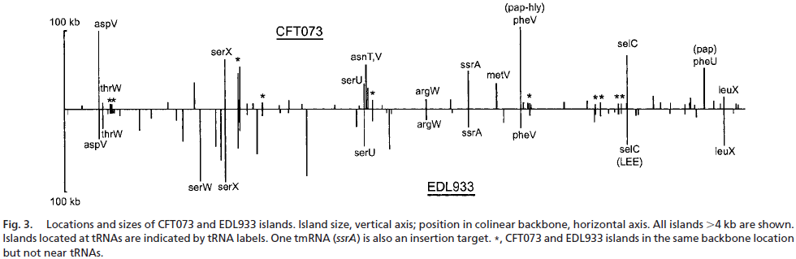

  The figure plots the size of pathogenicity islands of 2 strains against their relative positions on the shared backbone. Islands located at tRNA genes are labelled as well.  
  Since an ecotype is defined as a distinct type of organism occupying in a specific environment, and that a human body contains diverse unique enviromnents provided by different organs and bodily locations, there is a high diversity in the ecotypes of microbes who are adapted to live in each environment on the body.  
  To adapt to diverse environments, there must be specifc accessory genes. This is exemplified by the special adhesins present in CFT073 which enables it to resist urinary tract flushing.  
  Accessory genes are usually transferred horizontally which enables rapid development in pathogenicity and are subsequently vertically transmitted. The core set of essential genes, on the other hand, are usually only vertically transmitted during division.

### Module Essay

*Discuss the challenges involved in defining a microbial species and how HGT complicates matters, especially in the context of the evolution and phylogenetic distribution of microbial metabolic pathways. Can you comment on how HGT influences the maintenance of global biogeochemical cycles through time? Finally, do you think it is necessary to have a clear definition of a microbial species? Why or why not?*

The study of microbiology rests upon the ability to categorize concepts using informative and accepted definitions. Surprisingly however, the definition of microbial species remains to be refined. In relatively recent time, with the advent of next-generation genome sequencing technologies, it was gradually realized that the current working species definition is growing inadequate, evident through large intra-species diversity (Konstantinidis et al., 2006). This is in part due to horizontal gene transfer (HGT), a process by which genetic material is transferred and incorporated between two organisms by a mechanism other than reproduction. Rapid evolution facilitated by HGT contributes to the high observed intra-species diversity (Wiedenback et al., 2011). Phylogenetic distribution of metabolic pathways by HGT (Iwasaki & Takagi, 2009) may also contribute to intra-species diversity. In the interest of maintaining a clear species definition while taking into account the observed diversity, there may need to be a compromise between the traditional vertical information flow based classification system, and a novel system that models horizontal information flow.

**Issues of current microbial species definitions**  
The current microbial species definition is not without problems. Since the long-accepted species definition applies only to sexually reproducing organisms, this definition was adapted to asexually reproducing microbes. Since one of the bases of sexual reproduction was genetic similarity, the working definition for microbes incorporated such a notion. Two microbial genomes are said to belong to the same species if there is at least 70% DNA-DNA hybridization (DDH; Wayne, 1988), which correlates to approximately 97% 16S rRNA gene sequence similarity (Stackebrandt & Goebel, 1994). However in practice, there is great intra-species genotypic and phenotypic diversity (Konstantinidis et al., 2006). This finding may not come as a surprise as the 70% DDH criterium, when applied to mammals, would place humans together with chimpanzees and lemurs (98.4% & 78% DDH; Sibley & Ahlquist, 1987; Sibley et al., 1990). E. coli ecotypes MG1655 (non-pathogenic), CFT073 (uropathogenic), and EDL933 (enterohemorrhagic) were only found to share, by all, 39.2% of their combined set of genes (Welch et al., 2002). This raised to 51.1% for genes that were simply shared by any 2 strains. Consequently, the high intra-species diversity complicates phylogenetic analyses, and limits the information content of a species classification. The challenge therefore lies in increasing the information content of the microbial species definition while consistently representing the diverse set of observed features.

**Intra-species diversity facilitated by HGT**  
Natural selection is constantly at play in the survival of any organism. Organisms are expected to exploit every means possible. Consequently, they must rapidly adapt to their niches, which are diverse and often dynamic. Compared to vertical transmission of genes as a means of adaptation, HGT is orders of magnitude more frequent. This is readily seen in the development of antibiotic resistance, in which bacterial strains often acquire entire operons on a plasmid in a single event (Davies & Davies, 2010). Pairwise comparisons of genomes sequenced from 8 isolates of Acinetobacter baumanni from a single Mexican tertiary care center revealed a median of 296 gene differences, but only a median of 1.5 de novo mutations (Graña-Miraglia et al., 2017). Similarly, genomic islands, which are clusters of genes introduced via HGT, also confer adaptive advantages. Approximately 25% of CFT073âs genome belonged to genomic islands, enabling its uropathogenicity (Welch et al., 2002). Since bacterial diversification and evolution due to selection pressures is at least in part facilitated by HGT (Wiedenback et al., 2011), HGT therefore may also be responsible for intra-species diversity by transferring accessory genes peripheral to the central genomic backbone (Pál et al. 2005). The resulting diversity and rapid rate diversification complicates the improvement of microbial species definition.

**Phylogenetic distribution of metabolic pathways facilitated by HGT**  
In addition to rapid adaptation, organisms must also contend with the sheer diversity of niches. The human body alone offers an abundance of diverse environments, from the dry epidermal surface, to the wet genitourinary mucosa, to the acidic gastrointestinal lumen. With diverse environments comes an even greater variety of niches and the need to adapt, evident through the variety of E. coli strains specific for different human environments (Welch et al., 2002). HGT in this regard has also been considered as an efficient mechanism for incorporating novel biological pathways (PÃ¡l et al. 2005, Iwasaki & Takagi, 2009). Since one or more genes advantageous for a niche can be picked up and incorporated, HGT is often suggested as an explanation of pervasive phylogenetic presence of homologous metabolic genes, such as those belonging to the denitrification pathway (Jones et al., 2008). Additionally, HGT allows for streamlined metabolic pathway sharing between symbionts, which is observed in the endosymbiotic relationship between mealybugs and 2 bacterial species (Husnik et al., 2013). The role of HGT in providing efficient metabolism is also seen in the maintenance of global biogeochemical pathways throughout time. As HGT may be an explanation of phylogenetic distribution of homologous metabolic genes, it may be that microbes act as âguardians of metabolismâ (Falkowski et al., 2008) by maintaining a pervasive, accessible, and extensive library of metabolic genes, ready to be laterally transferred to another microbe. Given the vast variety of metabolic niches, it is unlikely that any gene would become extinct. Thus HGT may be a key factor in functionally maintaining global biogeochemical cycles by acting as a mechanism to mobilize genes along the phylogenetic tree of life, all the while contributing to the already great intra-species diversity.

**Necessity for a clear microbial species definition**  
Even faced with a multitude of challenges, it is nonetheless worthwhile to clearly define a microbial species. Human understanding, and consequently communication, rests heavily on our ability to consistently label ideas and observations. Development of a tractable and consistent definition while addressing the intra-species microbial diversity will be beneficial not only for the study of microbiology moving forward, but also for its application in fields such as medicine and biotechnology. It may be the case that current ideals for such a definition is too ambitious, as they concern with the integration of intra-species genotypic and phenotypic diversity in an inherently hierarchical model based on vertical information flow. Since the central conserved genomic backbone is vertically transmitted (PÃ¡l et al. 2005), while the peripheral accessory genes are often horizontally transferred, it may be viable to consider a bipartite microbial classification model consisting of a novel phenotypic classification in addition to the traditional phylogenetic classification. A phenotypic and/or functional classification system, which have greater information content at lower taxonomic classifications, may very well complement such a deficit observed in the current phylogeny based systems. Since HGT transcends traditional phylogenetic representations, addressing phenotypic diversity independent from phylogeny redirects the focus from vertical information flow, which is inapplicable to HGT, to a more practically applicable descriptor. Thus a bipartite genotypic-phenotypic classification model may reconcile the current microbial species framework with the observed intra-species diversity.

**Conclusion**  
The exact definition of microbial species has long been a debated topic. The current framework grows inadequate as we begin to observe greater intra-species genotypic and phenotypic diversity. It may be the case that selection pressure drives rapid evolution and diversification which is facilitated by HGT. HGT also contributes to intra-species diversity by enabling the distribution of homologous metabolic genes. As HGT is an integral part of the microbial existence, we must ensure a clear species and sub-species classification framework which is compatible with lateral information flow. A bipartite genotypic-phenotypic framework may present as a solution to this conundrum in order to accurately and consistently describe the wonderful diversity of the microbial world.

## References

1. Callahan BJ, Mcmurdie PJ, Holmes SP. Exact sequence variants should replace operational taxonomic units in marker-gene data analysis. ISME J. 2017;11(12):2639-2643.
2. Davies J, Davies D. Origins and evolution of antibiotic resistance. Microbiol Mol Biol Rev. 2010;74(3):417-33.
3. Falkowski PG, Fenchel T, Delong EF. The microbial engines that drive Earth’s biogeochemical cycles. Science. 2008;320(5879):1034-9.
4. Graña-miraglia L, Lozano LF, Velázquez C, et al. Rapid Gene Turnover as a Significant Source of Genetic Variation in a Recently Seeded Population of a Healthcare-Associated Pathogen. Front Microbiol. 2017;8:1817.
5. Hallam SJ, Torres-beltrÃ¡n M, Hawley AK. Monitoring microbial responses to ocean deoxygenation in a model oxygen minimum zone. Sci Data. 2017;4:170158.
6. Hawley AK, Torres-beltrÃ¡n M, Zaikova E, et al. A compendium of multi-omic sequence information from the Saanich Inlet water column. Sci Data. 2017;4:170160.
7. Husnik F, Nikoh N, Koga R, et al. Horizontal gene transfer from diverse bacteria to an insect genome enables a tripartite nested mealybug symbiosis. Cell. 2013;153(7):1567-78.
8. Iwasaki W, Takagi T. Rapid pathway evolution facilitated by horizontal gene transfers across prokaryotic lineages. PLoS Genet. 2009;5(3):e1000402.
9. Jones CM, Stres B, Rosenquist M, Hallin S. Phylogenetic analysis of nitrite, nitric oxide, and nitrous oxide respiratory enzymes reveal a complex evolutionary history for denitrification. Mol Biol Evol. 2008;25(9):1955-66.
10. Konstantinidis KT, Ramette A, Tiedje JM. The bacterial species definition in the genomic era. Philos Trans R Soc Lond, B, Biol Sci. 2006;361(1475):1929-40.
11. Kunin V, Engelbrektson A, Ochman H, Hugenholtz P. Wrinkles in the rare biosphere: pyrosequencing errors can lead to artificial inflation of diversity estimates. Environ Microbiol. 2010;12(1):118-23.
12. Lundin D, Severin I, Logue JB, Ostman O, Andersson AF, LindstrÃ¶m ES. Which sequencing depth is sufficient to describe patterns in bacterial Î±- and Î²-diversity?. Environ Microbiol Rep. 2012;4(3):367-72.
13. PÃ¡l C, Papp B, Lercher MJ. Adaptive evolution of bacterial metabolic networks by horizontal gene transfer. Nat Genet. 2005;37(12):1372-5.
14. Sibley CG, Ahlquist JE: DNA hybridization evidence of hominoid phylogeny: results from an expanded data set. J Mol Evol. 1987;26:99-121.
15. Sibley CG, Comstock JA, Ahlquist JE: DNA hybridization evidence of hominoid phylogeny: a reanalysis of the data. J Mol Evol. 1990;30:202-36.
16. Sogin ML, Morrison HG, Huber JA, et al. Microbial diversity in the deep sea and the underexplored “rare biosphere”. Proc Natl Acad Sci USA. 2006;103(32):12115-20.
17. Stackebrandt E, Goebel BM. Taxonomic note: a place for DNA-DNA reassociation and 16S rRNA sequence analysis in the present species definition in bacteriology. Int J Syst Evol Micr. 1994;44(4):846-9.
18. Torres-beltrÃ¡n M, Hawley AK, Capelle D, et al. A compendium of geochemical information from the Saanich Inlet water column. Sci Data. 2017;4:170159.
19. Wayne LG. International Committee on Systematic Bacteriology: announcement of the report of the ad hoc Committee on Reconciliation of Approaches to Bacterial Systematics. Zentralbl Bakteriol Mikrobiol Hyg A. 1988;268(4):433-4.
20. Welch RA, Burland V, Plunkett G, et al. Extensive mosaic structure revealed by the complete genome sequence of uropathogenic Escherichia coli. Proc Natl Acad Sci USA. 2002;99(26):17020-4.
21. Wiedenbeck J, Cohan FM. Origins of bacterial diversity through horizontal genetic transfer and adaptation to new ecological niches. FEMS Microbiol Rev. 2011;35(5):957-76.